# EVALUACION MIDTERM - Análisis de susceptibilidad a deslizamientos mediante regresión logística

Author

Ruben Basantes

Published

October 4, 2025

## 0. Importando librerias

Se importan las librerias desde los paquetes

```python
import pandas as pd
import numpy as np
import geopandas as gpd
import matplotlib.pyplot as plt
from sklearn.model_selection import train_test_split
from sklearn.preprocessing import StandardScaler
from sklearn.pipeline import Pipeline
from sklearn.linear_model import LogisticRegression
from sklearn.metrics import accuracy_score, precision_score, recall_score, f1_score, confusion_matrix, ConfusionMatrixDisplay, roc_curve, auc
from sklearn.impute import SimpleImputer
import seaborn as sns
```

## Qué se quiere modelar?

Se modelara la posibilidad de ocurrencia de un deslizamiento en funcion a las caracteristicas morfologicas , geologicas y climaticas en la provincia de imbabura. Para ello se ha construido una base de datos propia que parte desde el la variable dependiente (ocurrencia de un deslizamiento: si ocurre / no ocurre) y varias variables topograficas (pendiente, orientación, uso de suelo, indices morfologicos), climáticos (precipitacion).

## 1. Carga y exploración inicial del dataset.

Se cargan los datos geoespaciales del archivo .dbf, que proviene de una cobertura de puntos en formato shapefile.La tabla contiene atributos asociados a las localizaciones en las que se analizará la susceptibilidad a deslizamientos.

```python
df = gpd.read_file("desliz_db.dbf")
# Ver primeras filas
df.head()
```

|  | id | desliz | desliz_occ | elev1 | slp1 | asp1 | mincurv1 | maxcurv1 | tri1 | precobs1 | ... | MAX_TEXTUR | MIN_PRECOD | FIRST_PH1 | MIN_PROFUN | MIN_PEDREG | MIN_DRENAJ | MIN_INUNDA | MIN_CAPAFR | MIN_EROSIO | geometry |
| --- | --- | --- | --- | --- | --- | --- | --- | --- | --- | --- | --- | --- | --- | --- | --- | --- | --- | --- | --- | --- | --- |
| 0 | 567.0 | 4.0 | 0 | 4182 | 20.022005 | 95.237251 | 0.305461 | 6.235106 | 24.248711 | 1249.351074 | ... | 96.0 | 96.0 | 96 | 96.0 | 96.0 | 96.0 | 96.0 | 96.0 | 96.0 | None |
| 1 | 5094.0 | 4.0 | 0 | 4176 | 19.890425 | 90.028275 | 0.478023 | 6.623067 | 31.320919 | 1249.351074 | ... | 96.0 | 96.0 | 96 | 96.0 | 96.0 | 96.0 | 96.0 | 96.0 | 96.0 | None |
| 2 | 5114.0 | 5.0 | 0 | 4442 | 22.213970 | 37.469372 | -0.642612 | 6.319077 | 24.331051 | 1277.705688 | ... | 96.0 | 96.0 | 96 | 96.0 | 96.0 | 96.0 | 96.0 | 96.0 | 96.0 | None |
| 3 | 1982.0 | 1.0 | 1 | 2531 | 1.125581 | 300.382629 | 0.055037 | 3.728595 | 3.464102 | 1061.009277 | ... | 21.0 | 3.0 | 5.5-6.5 | 4.0 | 1.0 | 2.0 | 1.0 | 3.0 | 1.0 | None |
| 4 | 227.0 | 3.0 | 1 | 2208 | 7.031796 | 224.362350 | 0.055228 | 2.809405 | 4.358899 | 813.135376 | ... | 21.0 | 2.0 | 6.6-7.4 | 4.0 | 1.0 | 2.0 | 1.0 | 4.0 | 1.0 | None |

5 rows × 24 columns

Se identifican las variables con valores faltantes y se visualizan en un gráfico de barras. sto permite decidir si imputar valores o eliminar registros incompletos.

```
Porcentaje de valores faltantes por columna:
geometry      100.00
precobs1        1.20
CLASIF2         0.80
CLASS           0.80
desliz          0.15
MAX_TEXTUR      0.05
MIN_EROSIO      0.05
MIN_CAPAFR      0.05
MIN_INUNDA      0.05
MIN_DRENAJ      0.05
MIN_PEDREG      0.05
MIN_PROFUN      0.05
FIRST_PH1       0.05
MIN_PRECOD      0.05
MIN_PENDIE      0.05
MIN_TEXTUR      0.05
tri1            0.00
maxcurv1        0.00
mincurv1        0.00
asp1            0.00
slp1            0.00
elev1           0.00
desliz_occ      0.00
id              0.00
dtype: float64
```

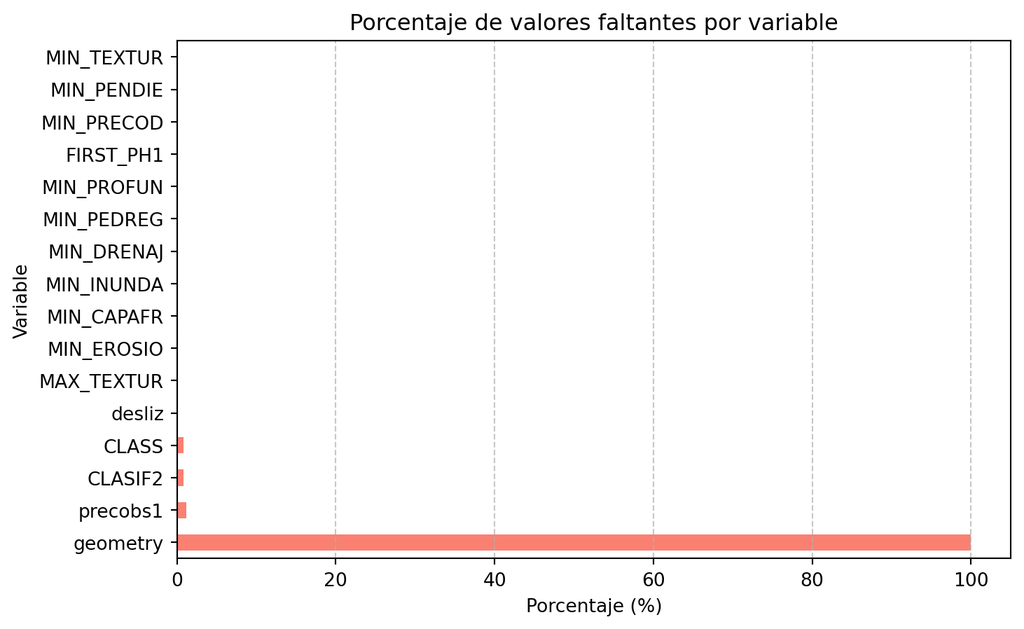

```python
# Porcentaje de valores faltantes por columna
nan_percent = df.isna().mean() * 100
nan_percent_sorted = nan_percent.sort_values(ascending=False).round(2)

print("Porcentaje de valores faltantes por columna:")
print(nan_percent_sorted)

# === Visualización opcional con gráfico de barras ===
nan_percent_sorted[nan_percent_sorted > 0].plot(
    kind='barh', color='salmon', figsize=(8,5)
)
plt.title("Porcentaje de valores faltantes por variable")
plt.xlabel("Porcentaje (%)")
plt.ylabel("Variable")
plt.grid(axis='x', linestyle='--', alpha=0.7)
plt.show()
```

La seleccion de seleccion de variables considera: desliz_occ: variable dependiente (0 = sin deslizamiento, 1 = con deslizamiento) features: variables explicativas derivadas del terreno o clima Se eliminan filas con valores faltantes.

```python
# La tercera columna ('desliz_occ') es la variable dependiente (0 = no, 1 = sí)
target_col = 'desliz_occ'

# Seleccion de variables explicativas numéricas
# Excluimos id, desliz, CLASIF2 (categórica), FIRST_PH1 (código de tipo), 'mincurv1', 'tri1', 'elev1',
# Puedes ajustar según tus columnas reales
features = [
    'slp1', 'asp1', 'mincurv1', 'precobs1',
    'CLASS',
]

# Eliminacion filas con NaN
df_clean = df.dropna(subset=features + [target_col])
```

```python
# Crear subconjunto de datos
X = df_clean[features]
y = df_clean[target_col].astype(int)

# Verificar valores faltantes
X.info()
X.describe()
```

```
<class 'pandas.core.frame.DataFrame'>
Index: 8127 entries, 0 to 8230
Data columns (total 5 columns):
 #   Column    Non-Null Count  Dtype
---  ------    --------------  -----
 0   slp1      8127 non-null   float64
 1   asp1      8127 non-null   float64
 2   mincurv1  8127 non-null   float64
 3   precobs1  8127 non-null   float64
 4   CLASS     8127 non-null   float64
dtypes: float64(5)
memory usage: 381.0 KB
```

|  | slp1 | asp1 | mincurv1 | precobs1 | CLASS |
| --- | --- | --- | --- | --- | --- |
| count | 8127.000000 | 8127.000000 | 8127.000000 | 8127.000000 | 8127.000000 |
| mean | 17.643405 | 179.408475 | 0.031628 | 1431.777205 | 6.559616 |
| std | 9.731685 | 106.421286 | 0.549215 | 524.563947 | 2.601635 |
| min | 0.000000 | 0.000003 | -3.604353 | 710.076965 | 1.000000 |
| 25% | 10.023978 | 86.005890 | -0.215386 | 960.355408 | 4.000000 |
| 50% | 16.839712 | 174.297424 | 0.039135 | 1357.765625 | 7.000000 |
| 75% | 24.342342 | 277.573380 | 0.274934 | 1783.895691 | 9.000000 |
| max | 61.854080 | 360.000000 | 3.151550 | 3052.468750 | 10.000000 |

La matriz de correlacion permite identificar colinealidad entre variables explicativas. Valores altos (>0.8 o <−0.8) pueden indicar redundancia entre variables.

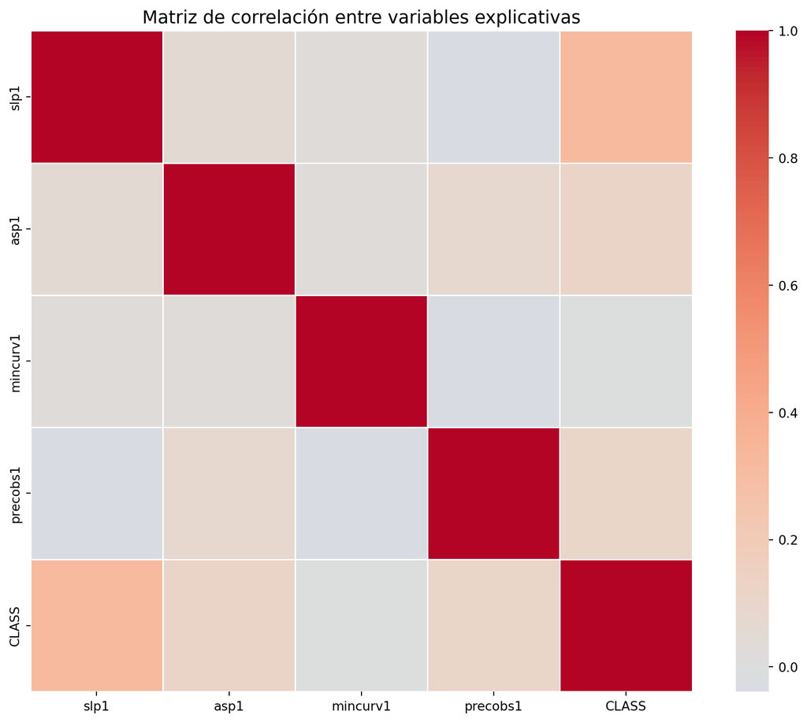

```python
# --- Asegurar que solo se usen variables numéricas ---
# --- Calcular la matriz de correlación ---
corr_matrix = X.corr(numeric_only=True)

# --- Mostrar los valores numéricos ---
corr_matrix.round(2)

# --- Visualizar la matriz de correlación con seaborn ---
plt.figure(figsize=(10, 8))
sns.heatmap(
    corr_matrix,
    annot=False,         # mostrar valores dentro de cada celda
    cmap='coolwarm',    # colores azul-rojo
    center=0,           # centrar en cero
    fmt=".2f",          # formato decimal
    square=True,
    linewidths=0.5
)
plt.title("Matriz de correlación entre variables explicativas", fontsize=14)
plt.tight_layout()
plt.show()
```

## 2. División en conjuntos de entrenamiento y prueba (train_test_split).

Se dividen los datos: - 70% para entrenar el modelo - 30% para evaluar su desempeño - La opción stratify=y asegura que la proporción de clases (desliz/no desliz) sea similar en ambos conjuntos.

```python
X_train, X_test, y_train, y_test = train_test_split(
    X, y, test_size=0.3, random_state=42, stratify=y
)

print("Tamaño del conjunto de entrenamiento:", X_train.shape)
print("Tamaño del conjunto de prueba:", X_test.shape)
```

```
Tamaño del conjunto de entrenamiento: (5688, 5)
Tamaño del conjunto de prueba: (2439, 5)
```

## 3. Definición y entrenamiento del modelo utilizando Pipeline.

Etapas del pipeline:

- Imputer: reemplaza valores faltantes por la media.
- Scaler: estandariza las variables (media = 0, desviación = 1).
- Regresión logística: modelo lineal que estima la probabilidad de deslizamiento.
- class_weight=‘balanced’: ajusta el peso de las clases para evitar sesgo hacia la clase mayoritaria.

```python
# Definir pipeline: estandarización + regresión logística
pipe = Pipeline([
    ('imputer', SimpleImputer(strategy='mean')),  # or 'median'
    ('scaler', StandardScaler()),
    ('logreg', LogisticRegression(solver='liblinear', class_weight='balanced',max_iter=1000))
])

# Entrenar modelo
pipe.fit(X_train, y_train)
```

```
Pipeline(steps=[('imputer', SimpleImputer()), ('scaler', StandardScaler()),
                ('logreg',
                 LogisticRegression(class_weight='balanced', max_iter=1000,
                                    solver='liblinear'))])
```

## 4. Generación de predicciones.

```python
y_pred = pipe.predict(X_test)
y_prob = pipe.predict_proba(X_test)[:, 1]
```

## 5. Evaluación del modelo con métricas apropiadas.

```python
acc = accuracy_score(y_test, y_pred)
prec = precision_score(y_test, y_pred)
rec = recall_score(y_test, y_pred)
f1 = f1_score(y_test, y_pred)
```

Accuracy de 0.659 indica que se trata de de un odelo que acierta en alrededro el 66 % de las predicciones totales. EL modelo Es un valor moderado, adecuado como punto de partida, pero no indica excelente desempeño dado que los errores (falsos positivos o negativos) aún son frecuentes.

```python
print(f"Accuracy:  {acc:.3f}")
```

```
Accuracy:  0.659
```

Precision 0.630 De todas las zonas predichas como susceptibles a deslizamiento, el 63 % realmente presenta evidencia de deslizamientos. Esto significa que existe una proporción moderada de falsas alarmas (falsos positivos).

```python
print(f"Precision: {prec:.3f}")
```

```
Precision: 0.630
```

Recall (Sensibilidad) 0.653 El modelo logra identificar correctamente el 65 % de las áreas donde realmente ocurrieron deslizamientos. Es decir, falla en detectar alrededor del 35 % de los casos reales, lo que puede ser relevante si el objetivo es prevenir riesgos.

```python
print(f"Recall:    {rec:.3f}")
```

```
Recall:    0.653
```

F1 Score 0.641 Representa el balance entre precisión y sensibilidad. Un valor de 0.64 sugiere que el modelo tiene un rendimiento equilibrado, pero todavía no óptimo para aplicaciones críticas de gestión del riesgo.

```python
print(f"F1-score: {f1:.3f}")
```

```
F1-score: 0.641
```

## 6. Visualizaciones e interpretación de resultados.

En la matriz de comfusion Diagonal principal → predicciones correctas. Fuera de la diagonal → errores del modelo.

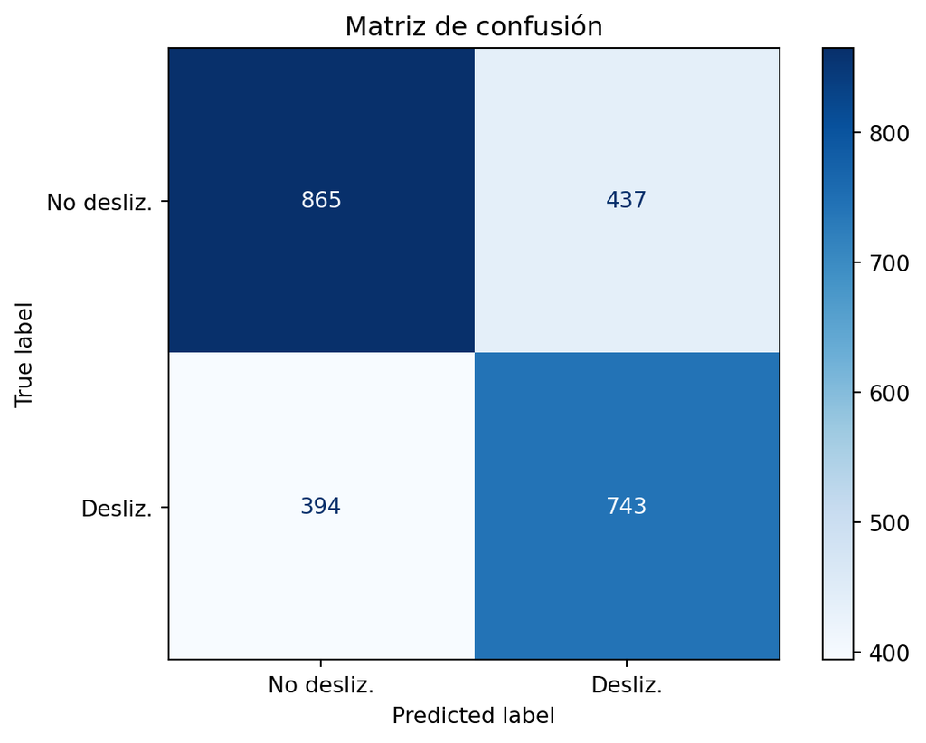

```python
# Matriz de confusion
cm = confusion_matrix(y_test, y_pred)
disp = ConfusionMatrixDisplay(confusion_matrix=cm, display_labels=["No desliz.", "Desliz."])
disp.plot(cmap='Blues')
plt.title("Matriz de confusión")
plt.show()
```

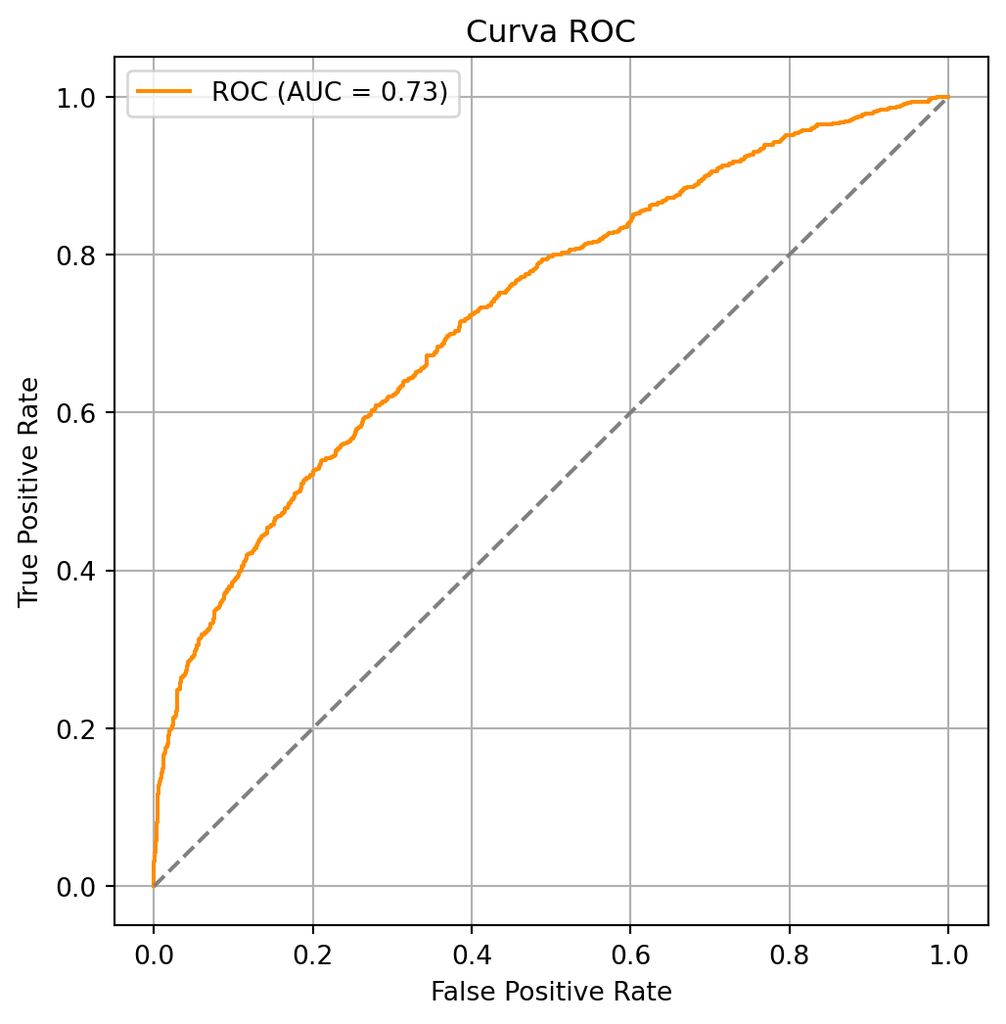

```python
# Curva ROC
fpr, tpr, thresholds = roc_curve(y_test, y_prob)
roc_auc = auc(fpr, tpr)

plt.figure(figsize=(6,6))
plt.plot(fpr, tpr, label=f'ROC (AUC = {roc_auc:.2f})', color='darkorange')
plt.plot([0,1], [0,1], linestyle='--', color='gray')
plt.xlabel("False Positive Rate")
plt.ylabel("True Positive Rate")
plt.title("Curva ROC")
plt.legend()
plt.grid(True)
plt.show()
```

La curva ROC representa la capacidad del modelo para distinguir entre áreas con y sin deslizamientos. En el eje X se muestra la tasa de “falsos positivos” y en el eje Y la tasa de “verdaderos positivos”. El valor del area cajo la curva (AUC) es 0.73, lo que implica:

🔹 Si se eligen al azar dos zonas, una con deslizamiento y otra sin deslizamiento, el modelo tiene un 73 % de probabilidad de asignar coincidor con la ocurrencia de un deslizamiento a la zona realmente afectada.

🔹 Un AUC = 0.73 demuestra que el modelo aprende patrones útiles de las variables explicativas.

🔹 El tramo más curvado hacia arriba en la gráfica indica que el modelo identifica correctamente una proporción considerable de zonas con deslizamiento, manteniendo una tasa razonablemente baja de falsos positivos.

```python
# Coeficientes del modelo
coef = pd.DataFrame({
    'Variable': features,
    'Coeficiente': pipe.named_steps['logreg'].coef_[0]
})
coef.sort_values(by='Coeficiente', ascending=False)
```

|  | Variable | Coeficiente |
| --- | --- | --- |
| 4 | CLASS | 0.057308 |
| 2 | mincurv1 | 0.019340 |
| 1 | asp1 | 0.004270 |
| 3 | precobs1 | -0.443803 |
| 0 | slp1 | -0.969595 |